# sport an R package for online update algorithms

Dawid Kałędkowski

2024-01-08

# About

Name `sport` is an abbreviation for Sequential Pairwise Online Rating Techniques. Package contains functions calculating ratings for two-player or multi-player matchups. Methods included in package are able to estimate ratings (players strengths) and their evolution in time, also able to predict output of challenge. Algorithms are based on Bayesian Approximation Method, and they don’t involve any matrix inversions nor likelihood estimation. `sport` incorporates glicko algorithm, glicko2, bayesian Bradley-Terry and dynamic logistic regression. Parameters are updated sequentially, and computation doesn’t require any additional RAM to make estimation feasible. Additionally, package is written in `c++` what makes computations even faster.

Before start, it’s recommended to read theoretical foundations of algorithms in other `sport` vignette “The theory of the online update algorithms”.

Package can be installed from CRAN or from github.

```r
install.packages("sport")
devtools::install_github("gogonzo/sport")
```

# Package Usage

## Available Data

Package contains actual data from Speedway Grand-Prix. There are two data.frames:

1. `gpheats` - results SGP heats. Column `rank` is a numeric version of column `position` - rider position in race.
2. `gpsquads` - summarized results of the events, with sum of point and final position.

```r
library(sport)
data <- gpheats[1:1002, ]
str(data)
```

```
## 'data.frame':    1002 obs. of  11 variables:
##  $ id      : num  1 1 1 1 2 2 2 2 3 3 ...
##  $ season  : int  1995 1995 1995 1995 1995 1995 1995 1995 1995 1995 ...
##  $ date    : POSIXct, format: "1995-05-20 19:00:00" "1995-05-20 19:00:00" ...
##  $ round   : int  1 1 1 1 1 1 1 1 1 1 ...
##  $ name    : chr  "Speedway Grand Prix of Poland" "Speedway Grand Prix of Poland" "Speedway Grand Prix of Poland" "Speedway Grand Prix of Poland" ...
##  $ heat    : int  1 1 1 1 2 2 2 2 3 3 ...
##  $ field   : int  3 2 1 4 4 2 1 3 3 2 ...
##  $ rider   : chr  "Chris Louis" "Gary Havelock" "Tomasz Gollob" "Tony Rickardsson" ...
##  $ points  : int  3 0 2 1 2 0 3 1 1 2 ...
##  $ position: chr  "1" "4" "2" "3" ...
##  $ rank    : num  1 4 2 3 2 4 1 3 3 2 ...
```

Data used in `sport` package must be in so called long format. Typically `data.frame` contains at least `id`, `name` of the player and `rank`, with one row for one player within specific match. Package allows for any number of players within event and allows ties also.

In all methods, output variable needs to be expressed as a rank/position in event. Don’t mix up rank output with typical 1-win, 0-lost. In `sport` package output for two player game should be coded as 1=winner 2=looser. Below example of two matches with 4 players each.

```
##   id             rider rank
## 1  1       Chris Louis    1
## 2  1     Gary Havelock    4
## 3  1     Tomasz Gollob    2
## 4  1  Tony Rickardsson    3
## 5  2 Henrik Gustafsson    2
## 6  2    Jan Staechmann    4
## 7  2     Sam Ermolenko    1
## 8  2     Tommy Knudsen    3
```

## Estimate dynamic ratings

```r
glicko <- glicko_run(formula = rank | id ~ player(rider), data = data)
glicko2 <- glicko2_run(formula = rank | id ~ player(rider), data = data)
bbt <- bbt_run(formula = rank | id ~ player(rider), data = data)
dbl <- dbl_run(formula = rank | id ~ player(rider), data = data)

print(glicko)
```

[output not shown]

## Output

Objects returned by `<method>_run` are of class `rating` and have their own `print` and `summary` which provides simple overview. `print.sport` shows  
condensed informations about model performance like accuracy and consistency of model predictions with observed probabilities. More precise overview are  
given by `summary` by showing ratings, ratings deviations and comparing model win probabilities with observed.

```r
summary(dbl)
```

```
## $formula
## rank | id ~ player(rider)
##
## $method
## [1] "dbl"
##
## $`Overall Accuracy`
## [1] 0.635
##
## $`Number of pairs`
## [1] 3000
##
## $r
##                       rider      r    rd
##  1:       rider=Chris Louis  0.355 0.048
```

[output cut: 26 more lines]

To visualize top n ratings with their 95% confidence interval one can use dedicated `plot.rating` function. For `dbl` method top coefficients are presented which doesn’t have to be player specific (ratings). It’s also possible to examine ratings evolution in time, by specifying `players` argument.

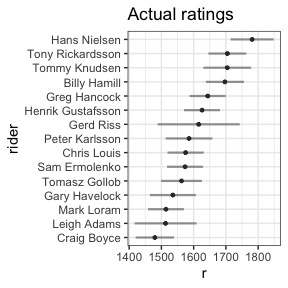

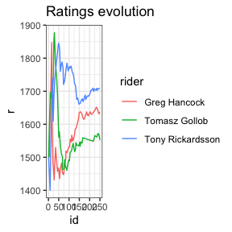

```r
plot(glicko, n = 15)
plot(glicko, players = c("Greg Hancock", "Tomasz Gollob", "Tony Rickardsson"))
```

Except dedicated `print`,`summary` and `plot` there is possibility to extract more detailed information for analyses. `rating` object contains following elements:

```r
names(glicko)
```

```
## [1] "final_r"  "final_rd" "r"        "pairs"
```

- `rating$final_r` and `rating$final_rd` contains the last estimate of the ratings and ratings deviations. For `glicko2` there is also `rating$final_sigma`.
- `r` contains `data.table` with prior ratings estimations from first event to the last. Number of rows in `r` equals number of rows in input data.
- `pairs` pairwise combinations of players in analyzed events with prior probability and result of a challenge.

```r
tail(glicko$r)
```

```
##     id          rider        r       rd
## 1: 250     Mark Loram 1514.506 28.44330
## 2: 250 Peter Karlsson 1597.472 37.17764
## 3: 250  Tomasz Gollob 1552.346 32.34887
## 4: 251    Chris Louis 1579.143 28.47306
## 5: 251    Craig Boyce 1477.183 30.23765
## 6: 251   Hans Nielsen 1778.792 34.01788
```

```r
tail(glicko$pairs)
```

```
##     id        rider     opponent Y         P
## 1: 251  Chris Louis  Craig Boyce 0 0.6415045
## 2: 251  Chris Louis Hans Nielsen 0 0.2426797
## 3: 251  Craig Boyce  Chris Louis 1 0.3584955
## 4: 251  Craig Boyce Hans Nielsen 0 0.1520817
## 5: 251 Hans Nielsen  Chris Louis 1 0.7573203
## 6: 251 Hans Nielsen  Craig Boyce 1 0.8479183
```

# Advanced sport

Examples presented in package overview might be sufficient in most cases, but sometimes it is necessary to adjust algorithms to fit data better. One characteristic of the online update algorithms is that variance of the parameters drops quickly to zero. Especially, when the number of events for the player is big ($n_i>100 $), after hundreds iterations rating parameters are very difficult to change, and output probabilities use to be extreme. To avoid these mistakes some additional controls should be applied, which is explained in this section with easy to learn examples.

## Formula

In all methods formula must contain `rank | id ~ player(player)` elements, to correctly specify the model.

- `rank` denotes column with output (order).
- `id` denotes event id, within which update is computed.
- `player(...)` function helps to identify column in which names of the players are stored. `player(...)` can be specified in two ways:
  1. `player(player)` if results of the event are observed per player.

     ```r
     glicko2 <- glicko2_run(
       formula = rank_player | id ~ player(player),
       data = data.frame(
         id = c(1, 1, 1, 1),
         player = c("a", "b", "c", "d"),
         rank_player = c(3, 4, 1, 2)
       )
     )
     ```

  2. `player(player | team)` when players competes within teams, and results are observed per team. This option is not available in `dbl_run` which requires only formula for player matchups.

     ```r
     glicko2 <- glicko2_run(
       formula = rank_team | id ~ player(player | team),
       data = data.frame(
         id = c(1, 1, 1, 1),
         team = c("A", "A", "B", "B"),
         player = c("a", "b", "c", "d"),
         rank_team = c(1, 1, 2, 2)
       )
     )
     ```

- other variables - available only in `dbl_run`, which allows to specify other factors in model.

  ```r
  dbl <- dbl_run(
  formula = rank | id ~ player(name) + gate * factor1,
  data = data.frame(
    id = c(1, 1, 1, 1),
    name = c("A", "B", "C", "D"),
    rank = c(3, 4, 1, 2),
    gate = c(1, 2, 3, 4),
    factor1 = c("a", "a", "b", "b"),
    factor2 = c("a", "b", "a", "b")
  )
  )
  ```

## Prior beliefs about `r` and `rd`

Main functionality which is common between all algorithms is to specify prior `r` and `rd`. Both parameters can be set by creating named vectors. Let’s suppose we have 4 players `c("A","B","C","D")` competing in an event, and we have players prior `r` and `rd` estimates. It’s important to have `r` and `rd` names corresponding with levels of `name` variable. One can run algorithm, to obtain new estimates.

```r
model <- glicko_run(
  formula = rank | id ~ player(rider),
  data = gpheats[1:16, ]
)
```

We can also run models re-using previously estimated parameters from `model$final_r` and `model$final_rd` in the future when new data appear.

```r
glicko_run(
  formula = rank | id ~ player(rider),
  data = gpheats[17:20, ],
  r = model$final_r,
  rd = model$final_rd
)$final_r
```

```
##       Chris Louis     Gary Havelock     Tomasz Gollob  Tony Rickardsson
##          1799.513          1200.487          1696.809          1400.162
## Henrik Gustafsson    Jan Staechmann     Sam Ermolenko     Tommy Knudsen
##          1599.838          1200.487          1940.042          1400.162
##        Andy Smith      Hans Nielsen        Mark Loram   Mikael Karlsson
##          1455.702          1599.838          1799.513          1200.487
##       Craig Boyce     Dariusz Śledź      Greg Hancock        Marvyn Cox
##          1508.129          1400.162          1599.838          1200.487
```

## Controlling update size by `weight`

All algorithms have a weight argument which increases or decreases update size. Higher weight increasing impact of corresponding event. Effect of the weight on update size can be expressed directly by following formula - $\small R_i^{'} \leftarrow R_i \pm \omega_i * \Omega_i$. To specify weight $\omega_i$ one needs to create additional column in input data, and pass the name of the column to `weight` argument. For example weight could depend on importance of competition. In speedway Grand-Prix last three heats determine event winner, thus they weight more.

## Avoiding excessive RD shrinkage with `kappa`

In situation when player plays games very frequently, `rd` can quickly decrease to zero, making further changes limited. Setting `kappa` (single value) avoids rating deviation decrease to be lower than specified fraction of `rd`. In other words final `rd` can’t be lower than initial `RD` times `kappa`

$$\small RD' \geq RD *
kappa$$

## Control output uncertainty by `lambda`

In some cases player ratings tend to be more uncertain. If scientist have prior knowledge about higher risk of event or uncertainty of specific player performance, then one might create another column with relevant values and pass the column name to `lambda` argument.

```r
# bbt example
data <- data %>%
  group_by(rider) %>%
  mutate(idle_30d = if_else(as.integer(date - lag(date)) > 30, 1.0, 2.0)) %>%
  filter(!is.na(idle_30d))

bbt <- bbt_run(
  formula = rank | id ~ player(rider),
  data = data,
  lambda = "idle_30d"
)
```

## Players nested within teams

In above examples players competes as individuals, and each is ranked at the finish line. There are sports where players, competes in teams, and results are reported per team. `sport` is able to compute player ratings, and requires only changing formula from `player(player)` to `player(player | team)`. `data.frame` should always be a long format, with one player for each row. Ratings are updated according to their contribution in team efforts. `share` argument can be added optionally if scientist have some knowledge about players contribution in match (eg. minutes spent on the field from all possible minutes).

```r
glicko2 <- glicko2_run(
  data = data.frame(
    id = c(1, 1, 1, 1),
    team = c("A", "A", "B", "B"),
    player = c("a", "b", "c", "d"),
    rank_team = c(1, 1, 2, 2),
    share = c(0.4, 0.6, 0.5, 0.5)
  ),
  formula = rank_team | id ~ player(player | team),
  share = "share"
)

glicko2$final_r
```

```
##        a        b        c        d
## 1583.660 1625.489 1394.845 1394.845
```

Output object contains the same elements as normal, with one difference - `pairs` contains probability and output per team, and `r` contains prior ratings per individuals.

```r
glicko2$pairs
```

```
##    id team opponent Y   P
## 1:  1    A        B 1 0.5
## 2:  1    B        A 0 0.5
```

```r
glicko2$r
```

```
##    id team player    r  rd sigma
## 1:  1    A      a 1500 350  0.05
## 2:  1    A      b 1500 350  0.05
## 3:  1    B      c 1500 350  0.05
## 4:  1    B      d 1500 350  0.05
```